# Week3Lecture

Author

Lianne Sheppard for ENVH 556 Autumn 2024

This document was rendered on September 25, 2024.

This is a companion document to the Week 3 lecture. Each slide with R code is represented in this document. This document also has a few additional alternative coding options.

## Slide 10: Simple regression scatterplot ln_nox on ln_no

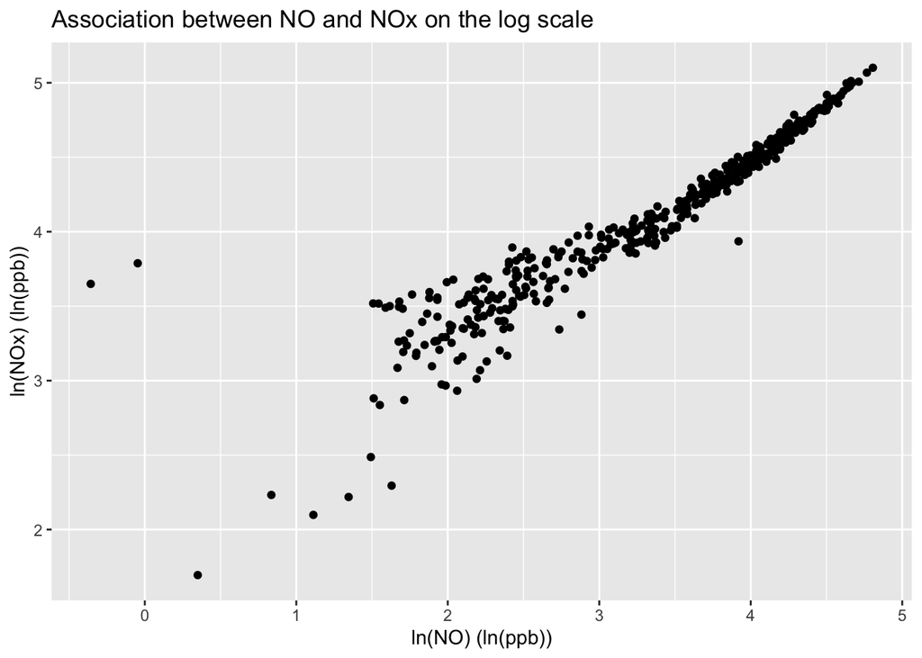

```r
#-----slide10----

(p <- ggplot(data=snapshot,aes(ln_no,ln_nox)) +
     geom_point() +
     labs(
        title="Association between NO and NOx on the log scale",
        x="ln(NO) (ln(ppb))",
        y="ln(NOx) (ln(ppb))"
    ) )
```

## Slide 12: Add regression line

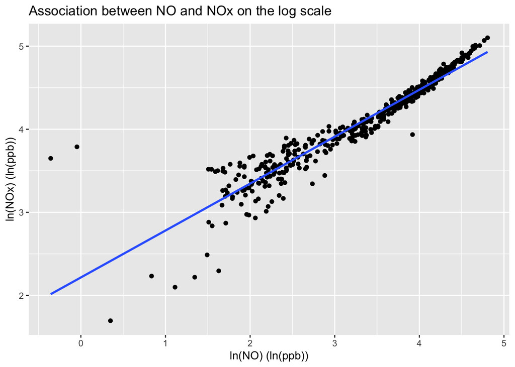

```r
#-----slide12----

p  + stat_smooth(method=lm, se=FALSE)
```

## Slide 13 + 14: Linear regression model

```r
#-----slide13+14----

# fit model
nox.fit <- lm(ln_nox ~ ln_no, data = snapshot)

# print summary, coefficients and CIs
summary(nox.fit)
```

```
Call:
lm(formula = ln_nox ~ ln_no, data = snapshot)

Residuals:
     Min       1Q   Median       3Q      Max
-0.84114 -0.05533  0.00054  0.06672  1.63554

Coefficients:
            Estimate Std. Error t value Pr(>|t|)
(Intercept) 2.215680   0.031943   69.36   <2e-16 ***
ln_no       0.564922   0.009283   60.85   <2e-16 ***
---
Signif. codes:  0 '***' 0.001 '**' 0.01 '*' 0.05 '.' 0.1 ' ' 1

Residual standard error: 0.1832 on 447 degrees of freedom
Multiple R-squared:  0.8923,    Adjusted R-squared:  0.8921
F-statistic:  3703 on 1 and 447 DF,  p-value: < 2.2e-16
```

```r
coef(nox.fit)
```

```
(Intercept)       ln_no
  2.2156798   0.5649221
```

```r
confint(nox.fit)
```

```
               2.5 %    97.5 %
(Intercept) 2.152903 2.2784568
ln_no       0.546678 0.5831662
```

```r
# variance-covariance matrix
vcov(nox.fit)
```

```
              (Intercept)         ln_no
(Intercept)  0.0010203520 -2.854654e-04
ln_no       -0.0002854654  8.617743e-05
```

```r
# # "tidy" option for summary, coefficients, and CIs
# from the broom package
summary_tbl <- tidy(nox.fit, conf.int = TRUE, conf.level = 0.95)
summary_tbl
```

```
# A tibble: 2 × 7
  term        estimate std.error statistic   p.value conf.low conf.high
  <chr>          <dbl>     <dbl>     <dbl>     <dbl>    <dbl>     <dbl>
1 (Intercept)    2.22    0.0319       69.4 2.14e-241    2.15      2.28
2 ln_no          0.565   0.00928      60.9 2.02e-218    0.547     0.583
```

## Slide 18

```r
#-----slide18----

# Should be basic description of the factor variable.
# season is the same variable as seasonfac, not as a factor and coded the same
# 1,2,3. Verify this by looking at the data:
summary(snapshot$seasonfac)
```

```
1Summer   2Fall 3Winter
    148     152     149
```

```r
summary(snapshot$season)
```

```
   Min. 1st Qu.  Median    Mean 3rd Qu.    Max.
  1.000   1.000   2.000   2.002   3.000   3.000
```

```r
table(snapshot$season)
```

```
  1   2   3
148 152 149
```

```r
table(snapshot$seasonfac)
```

```
1Summer   2Fall 3Winter
    148     152     149
```

```r
table(snapshot$seasonfac,snapshot$season)
```

```
            1   2   3
  1Summer 148   0   0
  2Fall     0 152   0
  3Winter   0   0 149
```

## Slide 19

```r
#-----slide19----

nox.aov<-lm(ln_nox ~ seasonfac, data = snapshot)
anova(nox.aov)
```

```
Analysis of Variance Table

Response: ln_nox
           Df Sum Sq Mean Sq F value    Pr(>F)
seasonfac   2 88.797  44.398  392.29 < 2.2e-16 ***
Residuals 446 50.477   0.113
---
Signif. codes:  0 '***' 0.001 '**' 0.01 '*' 0.05 '.' 0.1 ' ' 1
```

```r
summary(nox.aov)
```

```
Call:
lm(formula = ln_nox ~ seasonfac, data = snapshot)

Residuals:
     Min       1Q   Median       3Q      Max
-1.77479 -0.20277  0.04513  0.23392  0.97221

Coefficients:
                 Estimate Std. Error t value Pr(>|t|)
(Intercept)       3.46913    0.02765  125.45   <2e-16 ***
seasonfac2Fall    0.80043    0.03885   20.60   <2e-16 ***
seasonfac3Winter  1.04536    0.03904   26.77   <2e-16 ***
---
Signif. codes:  0 '***' 0.001 '**' 0.01 '*' 0.05 '.' 0.1 ' ' 1

Residual standard error: 0.3364 on 446 degrees of freedom
Multiple R-squared:  0.6376,    Adjusted R-squared:  0.6359
F-statistic: 392.3 on 2 and 446 DF,  p-value: < 2.2e-16
```

```r
#model.matrix(nox.aov)
margin.table(model.matrix(nox.aov), 2)
```

```
     (Intercept)   seasonfac2Fall seasonfac3Winter
             449              152              149
```

## Slide 20: add means of ln_nox by season

For example of interpreting dummy variables

```r
#-----slide20----

# Simple row of means of ln_nox by season
round(tapply(snapshot$ln_nox, snapshot$seasonfac, mean), 2)
```

```
1Summer   2Fall 3Winter
   3.47    4.27    4.51
```

```r
# # dplyr option (same results, output is formatted differently)
snapshot %>%
    group_by(seasonfac) %>%
    summarise(mean(ln_nox), .groups = "drop") %>%
    mutate_if(is.numeric, round, 2)
```

```
# A tibble: 3 × 2
  seasonfac `mean(ln_nox)`
  <fct>              <dbl>
1 1Summer             3.47
2 2Fall               4.27
3 3Winter             4.51
```

```r
# full table of N, means & sd of ln_nox by season, dplyr option
snapshot %>%
    group_by(seasonfac) %>%
    summarise(N = n(),
              mean = mean(ln_nox),
              sd = sd(ln_nox),
              .groups = "drop") %>%
    mutate_if(is.double, round, 2)
```

```
# A tibble: 3 × 4
  seasonfac     N  mean    sd
  <fct>     <int> <dbl> <dbl>
1 1Summer     148  3.47  0.39
2 2Fall       152  4.27  0.32
3 3Winter     149  4.51  0.3
```

## Slide 21: Be aware of coding!

```r
#-----slide21----

nox.aov2<-lm(ln_nox~season, data=snapshot)
anova(nox.aov2)
```

```
Analysis of Variance Table

Response: ln_nox
           Df Sum Sq Mean Sq F value    Pr(>F)
season      1 81.040   81.04  622.07 < 2.2e-16 ***
Residuals 447 58.233    0.13
---
Signif. codes:  0 '***' 0.001 '**' 0.01 '*' 0.05 '.' 0.1 ' ' 1
```

```r
summary(nox.aov2)
```

```
Call:
lm(formula = ln_nox ~ season, data = snapshot)

Residuals:
     Min       1Q   Median       3Q      Max
-1.86913 -0.20422  0.00437  0.23548  0.91107

Coefficients:
            Estimate Std. Error t value Pr(>|t|)
(Intercept)  3.04111    0.04526   67.19   <2e-16 ***
season       0.52237    0.02094   24.94   <2e-16 ***
---
Signif. codes:  0 '***' 0.001 '**' 0.01 '*' 0.05 '.' 0.1 ' ' 1

Residual standard error: 0.3609 on 447 degrees of freedom
Multiple R-squared:  0.5819,    Adjusted R-squared:  0.5809
F-statistic: 622.1 on 1 and 447 DF,  p-value: < 2.2e-16
```

## Slide 22: Season-stratified analysis example: means of ln_nox, ln_no by season

```r
#-----define summary function----

summary_stats <- function(df = snapshot, summary_var, grouping_var = seasonfac,
                          digits = 2){

  # specify names & variables for non-standard evaluation
  grouping_var <- enquo(grouping_var)
  summary_var <- enquo(summary_var)
  summary_name <- quo_name(summary_var)

  # create names for summary stats
  summary_name_N <- paste0(summary_name, ".N")
  summary_name_mean <- paste0(summary_name, ".mean")
  summary_name_sd <- paste0(summary_name, ".sd")

  # create summary
  df %>%
    group_by(!!grouping_var) %>%
    summarise(!!summary_name_N := n(),
              !!summary_name_mean := mean(!!summary_var),
              !!summary_name_sd := sd(!!summary_var),
              .groups = "drop") %>%
    mutate_if(is.double, round, digits)
}
```

```r
#-----slide22-------------------------

# ln_nox
summary_stats(summary_var = ln_nox)
```

```
# A tibble: 3 × 4
  seasonfac ln_nox.N ln_nox.mean ln_nox.sd
  <fct>        <int>       <dbl>     <dbl>
1 1Summer        148        3.47      0.39
2 2Fall          152        4.27      0.32
3 3Winter        149        4.51      0.3
```

```r
# ln_no
summary_stats(summary_var = ln_no)
```

```
# A tibble: 3 × 4
  seasonfac ln_no.N ln_no.mean ln_no.sd
  <fct>       <int>      <dbl>    <dbl>
1 1Summer       148       2.22     0.58
2 2Fall         152       3.65     0.5
3 3Winter       149       4.06     0.42
```

```r
# ln_nox and ln_no
full_join(summary_stats(summary_var = ln_nox),
          summary_stats(summary_var = ln_no),
          by = "seasonfac")
```

```
# A tibble: 3 × 7
  seasonfac ln_nox.N ln_nox.mean ln_nox.sd ln_no.N ln_no.mean ln_no.sd
  <fct>        <int>       <dbl>     <dbl>   <int>      <dbl>    <dbl>
1 1Summer        148        3.47      0.39     148       2.22     0.58
2 2Fall          152        4.27      0.32     152       3.65     0.5
3 3Winter        149        4.51      0.3      149       4.06     0.42
```

## Slide 23: Scatterplot with 3 season-specific lines

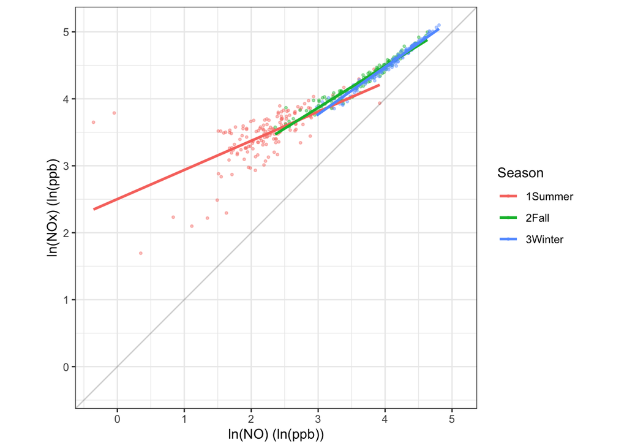

```r
#-----slide23----

# ggplot with separate colors and lines by season
ggplot(snapshot, mapping = aes(x = ln_no, y = ln_nox, color = seasonfac)) +
    geom_point(alpha = .4, size=.7) +
    stat_smooth(method = lm, se=FALSE) +
    #geom_rug(position="jitter", size=.2) +
    xlim(range(snapshot$ln_no, snapshot$ln_nox)) +
    ylim(range(snapshot$ln_no, snapshot$ln_nox)) +
    geom_abline(slope = 1, intercept = 0, alpha = .2, color = "black") +
    coord_fixed() +
    labs(x="ln(NO) (ln(ppb))", y="ln(NOx) (ln(ppb)", color="Season") +
    theme_bw()
```

## Slide 25: Season-specific regression

Summarize each season-specific model

```r
#-----slide25----

# season-specific regressions, as shown on slide (only subset of output)
summary(lm(ln_nox ~ ln_no, data = snapshot, subset = seasonfac == "1Summer"))
```

```
Call:
lm(formula = ln_nox ~ ln_no, data = snapshot, subset = seasonfac ==
    "1Summer")

Residuals:
     Min       1Q   Median       3Q      Max
-0.96001 -0.09415  0.00218  0.15193  1.30632

Coefficients:
            Estimate Std. Error t value Pr(>|t|)
(Intercept)  2.50219    0.09506   26.32   <2e-16 ***
ln_no        0.43544    0.04141   10.52   <2e-16 ***
---
Signif. codes:  0 '***' 0.001 '**' 0.01 '*' 0.05 '.' 0.1 ' ' 1

Residual standard error: 0.2932 on 146 degrees of freedom
Multiple R-squared:  0.431, Adjusted R-squared:  0.4271
F-statistic: 110.6 on 1 and 146 DF,  p-value: < 2.2e-16
```

```r
summary(lm(ln_nox ~ ln_no, data = snapshot, subset = seasonfac == "2Fall"))
```

```
Call:
lm(formula = ln_nox ~ ln_no, data = snapshot, subset = seasonfac ==
    "2Fall")

Residuals:
      Min        1Q    Median        3Q       Max
-0.172004 -0.032667 -0.000707  0.035451  0.298811

Coefficients:
            Estimate Std. Error t value Pr(>|t|)
(Intercept)  2.00416    0.03924   51.07   <2e-16 ***
ln_no        0.62102    0.01066   58.26   <2e-16 ***
---
Signif. codes:  0 '***' 0.001 '**' 0.01 '*' 0.05 '.' 0.1 ' ' 1

Residual standard error: 0.06551 on 150 degrees of freedom
Multiple R-squared:  0.9577,    Adjusted R-squared:  0.9574
F-statistic:  3394 on 1 and 150 DF,  p-value: < 2.2e-16
```

```r
summary(lm(ln_nox ~ ln_no, data = snapshot, subset = seasonfac == "3Winter"))
```

```
Call:
lm(formula = ln_nox ~ ln_no, data = snapshot, subset = seasonfac ==
    "3Winter")

Residuals:
     Min       1Q   Median       3Q      Max
-0.12209 -0.02501  0.00524  0.02654  0.14184

Coefficients:
            Estimate Std. Error t value Pr(>|t|)
(Intercept) 1.647180   0.036554   45.06   <2e-16 ***
ln_no       0.707100   0.008967   78.85   <2e-16 ***
---
Signif. codes:  0 '***' 0.001 '**' 0.01 '*' 0.05 '.' 0.1 ' ' 1

Residual standard error: 0.04555 on 147 degrees of freedom
Multiple R-squared:  0.9769,    Adjusted R-squared:  0.9767
F-statistic:  6218 on 1 and 147 DF,  p-value: < 2.2e-16
```

Here’s an alternative way to code the season-specific modeling approach using tidyverse. This allows you to run the regressions for each group in one command. More code, but these are coding ideas that will generalize to future settings where the number of subsets would make this a much more sensible approach.

```r
#----slide25.dplyr----

# # dplyr option
# Need to load the broom, purrr, & tidyr packages for this approach
season_mdls <- snapshot %>%

  # group by season
  group_by(seasonfac) %>%

  # nest the tibble
  nest() %>%

  # run regression model for each group, clean up with `tidy()`
  mutate(model = map(data, ~lm(ln_nox ~ ln_no, data = .x)),
         summary = map(model, summary),
         tidied = map(model, tidy)
         ) %>%

  # unnest
  unnest(tidied)

# show seasonal model summaries
season_mdls$summary %>% unique()
```

```
[[1]]

Call:
lm(formula = ln_nox ~ ln_no, data = .x)

Residuals:
     Min       1Q   Median       3Q      Max
-0.96001 -0.09415  0.00218  0.15193  1.30632

Coefficients:
            Estimate Std. Error t value Pr(>|t|)
(Intercept)  2.50219    0.09506   26.32   <2e-16 ***
ln_no        0.43544    0.04141   10.52   <2e-16 ***
---
Signif. codes:  0 '***' 0.001 '**' 0.01 '*' 0.05 '.' 0.1 ' ' 1

Residual standard error: 0.2932 on 146 degrees of freedom
Multiple R-squared:  0.431, Adjusted R-squared:  0.4271
F-statistic: 110.6 on 1 and 146 DF,  p-value: < 2.2e-16


[[2]]

Call:
lm(formula = ln_nox ~ ln_no, data = .x)

Residuals:
      Min        1Q    Median        3Q       Max
-0.172004 -0.032667 -0.000707  0.035451  0.298811

Coefficients:
            Estimate Std. Error t value Pr(>|t|)
(Intercept)  2.00416    0.03924   51.07   <2e-16 ***
ln_no        0.62102    0.01066   58.26   <2e-16 ***
---
Signif. codes:  0 '***' 0.001 '**' 0.01 '*' 0.05 '.' 0.1 ' ' 1

Residual standard error: 0.06551 on 150 degrees of freedom
Multiple R-squared:  0.9577,    Adjusted R-squared:  0.9574
F-statistic:  3394 on 1 and 150 DF,  p-value: < 2.2e-16


[[3]]

Call:
lm(formula = ln_nox ~ ln_no, data = .x)

Residuals:
     Min       1Q   Median       3Q      Max
-0.12209 -0.02501  0.00524  0.02654  0.14184

Coefficients:
            Estimate Std. Error t value Pr(>|t|)
(Intercept) 1.647180   0.036554   45.06   <2e-16 ***
ln_no       0.707100   0.008967   78.85   <2e-16 ***
---
Signif. codes:  0 '***' 0.001 '**' 0.01 '*' 0.05 '.' 0.1 ' ' 1

Residual standard error: 0.04555 on 147 degrees of freedom
Multiple R-squared:  0.9769,    Adjusted R-squared:  0.9767
F-statistic:  6218 on 1 and 147 DF,  p-value: < 2.2e-16
```

## Slide 26: Season-adjusted regression

```r
#-----slide26 season adjusted----

# season-adjusted regression
nox.fit.seasadj <-lm(ln_nox ~ ln_no + seasonfac, data = snapshot)

summary(nox.fit.seasadj)
```

```
Call:
lm(formula = ln_nox ~ ln_no + seasonfac, data = snapshot)

Residuals:
     Min       1Q   Median       3Q      Max
-0.84378 -0.05616  0.00276  0.06878  1.62058

Coefficients:
                 Estimate Std. Error t value Pr(>|t|)
(Intercept)      2.228426   0.041074  54.253   <2e-16 ***
ln_no            0.558718   0.017205  32.474   <2e-16 ***
seasonfac2Fall   0.003014   0.032432   0.093    0.926
seasonfac3Winter 0.020451   0.038071   0.537    0.591
---
Signif. codes:  0 '***' 0.001 '**' 0.01 '*' 0.05 '.' 0.1 ' ' 1

Residual standard error: 0.1835 on 445 degrees of freedom
Multiple R-squared:  0.8924,    Adjusted R-squared:  0.8917
F-statistic:  1231 on 3 and 445 DF,  p-value: < 2.2e-16
```

```r
confint(nox.fit.seasadj)
```

```
                       2.5 %     97.5 %
(Intercept)       2.14770200 2.30915004
ln_no             0.52490457 0.59253047
seasonfac2Fall   -0.06072550 0.06675330
seasonfac3Winter -0.05437144 0.09527248
```

## Slide 27: Be aware of coding!

Season as a continuous variable

```r
#-----slide27----

# Season as a continuous variable

# Fit the linear regression with continuous season variable
summary(lm(ln_nox ~ ln_no + season, data = snapshot))
```

```
Call:
lm(formula = ln_nox ~ ln_no + season, data = snapshot)

Residuals:
     Min       1Q   Median       3Q      Max
-0.84335 -0.05576  0.00133  0.06747  1.61576

Coefficients:
            Estimate Std. Error t value Pr(>|t|)
(Intercept)  2.21965    0.03244  68.420   <2e-16 ***
ln_no        0.55607    0.01550  35.880   <2e-16 ***
season       0.01266    0.01775   0.713    0.476
---
Signif. codes:  0 '***' 0.001 '**' 0.01 '*' 0.05 '.' 0.1 ' ' 1

Residual standard error: 0.1833 on 446 degrees of freedom
Multiple R-squared:  0.8924,    Adjusted R-squared:  0.8919
F-statistic:  1850 on 2 and 446 DF,  p-value: < 2.2e-16
```

```r
# Compare to the regression on the previous slide
```

## Slide 29: Interaction model

Need to load the `car` package for the `linearHypothesis` command. It masks at least one object from several other packages, so don’t load if you don’t need it. You can explicitly tell R which package to use with the “packagename::” prefix to a function or object.

```r
#-----slide29----

# interaction model
snap_int <- lm(ln_nox ~ ln_no * seasonfac, data = snapshot)
summary(snap_int)
```

```
Call:
lm(formula = ln_nox ~ ln_no * seasonfac, data = snapshot)

Residuals:
     Min       1Q   Median       3Q      Max
-0.96001 -0.04317  0.00148  0.04709  1.30632

Coefficients:
                       Estimate Std. Error t value Pr(>|t|)
(Intercept)             2.50219    0.05660  44.209  < 2e-16 ***
ln_no                   0.43544    0.02465  17.661  < 2e-16 ***
seasonfac2Fall         -0.49803    0.11891  -4.188 3.40e-05 ***
seasonfac3Winter       -0.85501    0.15111  -5.658 2.75e-08 ***
ln_no:seasonfac2Fall    0.18559    0.03761   4.934 1.14e-06 ***
ln_no:seasonfac3Winter  0.27166    0.04230   6.422 3.47e-10 ***
---
Signif. codes:  0 '***' 0.001 '**' 0.01 '*' 0.05 '.' 0.1 ' ' 1

Residual standard error: 0.1746 on 443 degrees of freedom
Multiple R-squared:  0.9031,    Adjusted R-squared:  0.902
F-statistic: 825.3 on 5 and 443 DF,  p-value: < 2.2e-16
```

```r
# F test for significant interaction from the car package
linearHypothesis(snap_int, c("ln_no:seasonfac2Fall=0", "ln_no:seasonfac3Winter=0"),
                 test="F")
```

```
Linear hypothesis test

Hypothesis:
ln_no:seasonfac2Fall = 0
ln_no:seasonfac3Winter = 0

Model 1: restricted model
Model 2: ln_nox ~ ln_no * seasonfac

  Res.Df    RSS Df Sum of Sq      F    Pr(>F)
1    445 14.979
2    443 13.502  2    1.4767 24.225 1.037e-10 ***
---
Signif. codes:  0 '***' 0.001 '**' 0.01 '*' 0.05 '.' 0.1 ' ' 1
```

## Slide 30: “lincom” coeficient estimates

Note: This can be done using the `glht` command from the `multcomp` package. This will mask several objects from other packages including `select` from `dplyr`, and `boxcox` from `EnvStats`.

Here is an example I found online:

```
# mod is the output of a lm
# Extract the coefficient names (b0,b1,b2,b3)
names(coef(mod))
# linfct specifies the required combination In this case we want b1+b3=0
# (effect of gender in age>40)
summary(glht(mod, linfct = c("genderMale + genderMale:agehiTRUE = 0")))
# Show the confidence interval
mod.lh <- glht(mod, linfct = c("genderMale + genderMale:agehiTRUE = 0"))
confint(mod.lh)
```

```r
#-----find means----

# Note:  this does not require snapshot to be a tibble
snapshot %>%
    group_by(seasonfac) %>%
    summarise(N = length(ln_nox),
              ln_no_mean = mean(ln_no),
              ln_nox_mean = mean(ln_nox),
              ln_nox_sd = sd(ln_nox),
              ln_nox_LCI = ln_nox_mean - 1.96*ln_nox_sd / sqrt(N),
              ln_nox_UCI = ln_nox_mean + 1.96*ln_nox_sd / sqrt(N)
              )
```

```
# A tibble: 3 × 7
  seasonfac     N ln_no_mean ln_nox_mean ln_nox_sd ln_nox_LCI ln_nox_UCI
  <fct>     <int>      <dbl>       <dbl>     <dbl>      <dbl>      <dbl>
1 1Summer     148       2.22        3.47     0.387       3.41       3.53
2 2Fall       152       3.65        4.27     0.317       4.22       4.32
3 3Winter     149       4.06        4.51     0.299       4.47       4.56
```

```r
#-----slide30 lincom example----

# Estimate the mean ln(NOx) when ln(NO) is 4

# Show the coefficient names.  Their order is needed for the K matrix definition
# so we know which values go in which column
names(coef(snap_int))
```

```
[1] "(Intercept)"            "ln_no"                  "seasonfac2Fall"
[4] "seasonfac3Winter"       "ln_no:seasonfac2Fall"   "ln_no:seasonfac3Winter"
```

```r
# K is the matrix of contrasts of interest to create the linear combination of
# the coefficients times the values in K.  Each row is for a contrast of
# interest.  The values in the rows are ordered by the coefficients. First row
# is summer when ln_no is 4, then same question for fall, then winter
K <- rbind(summer = c(1,4,0,0,0,0),
           fall   = c(1,4,1,0,4,0),
           winter = c(1,4,0,1,0,4))

colnames(K) <- names(coef(snap_int))

K
```

```
       (Intercept) ln_no seasonfac2Fall seasonfac3Winter ln_no:seasonfac2Fall
summer           1     4              0                0                    0
fall             1     4              1                0                    4
winter           1     4              0                1                    0
       ln_no:seasonfac3Winter
summer                      0
fall                        0
winter                      4
```

```r
# estimate the summer, fall, winter effects simultaneously
season_effects <- glht(snap_int, linfct = K)
summary(season_effects)
```

```
     Simultaneous Tests for General Linear Hypotheses

Fit: lm(formula = ln_nox ~ ln_no * seasonfac, data = snapshot)

Linear Hypotheses:
            Estimate Std. Error t value Pr(>|t|)
summer == 0  4.24393    0.04616   91.94   <2e-16 ***
fall == 0    4.48825    0.01734  258.88   <2e-16 ***
winter == 0  4.47558    0.01443  310.22   <2e-16 ***
---
Signif. codes:  0 '***' 0.001 '**' 0.01 '*' 0.05 '.' 0.1 ' ' 1
(Adjusted p values reported -- single-step method)
```

```r
# and get its CI
confint(season_effects)
```

```
     Simultaneous Confidence Intervals

Fit: lm(formula = ln_nox ~ ln_no * seasonfac, data = snapshot)

Quantile = 2.3963
95% family-wise confidence level


Linear Hypotheses:
            Estimate lwr    upr
summer == 0 4.2439   4.1333 4.3545
fall == 0   4.4883   4.4467 4.5298
winter == 0 4.4756   4.4410 4.5102
```

## Slide 32: example residual analysis plots

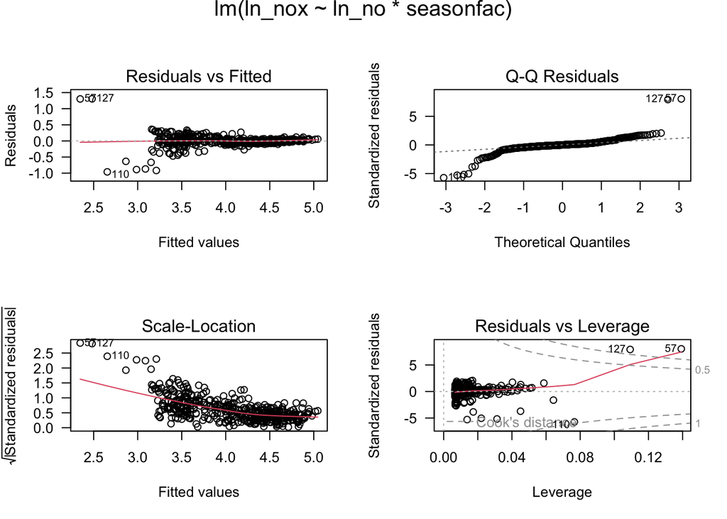

```r
#-----Slide32 default residuals----

# IDRE example from https://stats.idre.ucla.edu/r/dae/robust-regression/
opar <- par(mfrow = c(2,2), oma = c(0, 0, 1.1, 0))
plot(snap_int, las = 1)
```

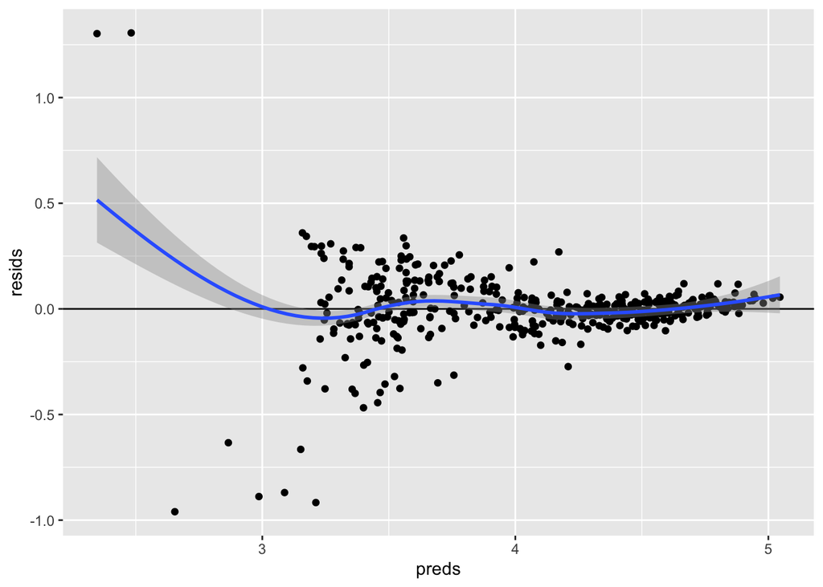

```r
#-----a basic residual plot----

# first add data to the snapshot data frame with `modlr` functions
snapshot2 <- snapshot %>%
    add_residuals(snap_int,"resids") %>%
    add_predictions(snap_int,"preds")

# then make scatterplot
ggplot(snapshot2, aes(x = preds, y = resids)) +
    geom_point() +
    geom_abline(slope = 0, intercept = 0) +
    geom_smooth(method = "loess")
```

## Slide 35: Regression for prediction – starting to replicate Table 4 of Mercer et al Summer

```r
#-----slide35----

# replicate the summer model in Table 4
# First create a summer only dataset with only the variables of interest

# specify covariates of interest (omitting outcome variable)
vars <- c("D2A1", "A1_50", "A23_400", "Pop_5000", "D2C", "Int_3000", "D2Comm")

# create dataframe
summer <- snapshot %>%
    dplyr::filter(season == 1) %>%
    dplyr::select(ln_nox, all_of(vars))

# specify regression formula
frml <- as.formula(paste("ln_nox ~ ", paste(vars, collapse = "+") ) )

# fit regression model
summer_mod <- lm(frml, data = summer)

# show the results
summary(summer_mod)
```

```
Call:
lm(formula = frml, data = summer)

Residuals:
     Min       1Q   Median       3Q      Max
-0.57337 -0.10017 -0.00186  0.11208  0.65811

Coefficients:
             Estimate Std. Error t value Pr(>|t|)
(Intercept)   2.99774    0.18905  15.857  < 2e-16 ***
D2A1         -0.27239    0.03670  -7.421 1.02e-11 ***
A1_50       -10.92040    7.64102  -1.429  0.15518
A23_400       0.34994    0.27533   1.271  0.20584
Pop_5000     -0.02557    0.01785  -1.433  0.15421
D2C           7.11637    0.41542  17.130  < 2e-16 ***
Int_3000      1.85241    0.57055   3.247  0.00146 **
D2Comm       -1.09132    0.83369  -1.309  0.19267
---
Signif. codes:  0 '***' 0.001 '**' 0.01 '*' 0.05 '.' 0.1 ' ' 1

Residual standard error: 0.2081 on 140 degrees of freedom
Multiple R-squared:  0.7252,    Adjusted R-squared:  0.7114
F-statistic: 52.78 on 7 and 140 DF,  p-value: < 2.2e-16
```

## Slide 36: Regression for prediction: getting fitted values and SE of mean vs new value PLUS show R2=square of correlation

Resulting correlation should be about .85 to get the estimated R2 of .7252.

```r
#-----slide36 fitted values and residuals----

#Note:  Dropping the use of a new "summer2" dataframe as not needed.  Slides introduce a new data frame

# Then add the predictions (and the residuals to the dataset)
summer <- summer %>%
    add_residuals(summer_mod,"resids") %>%
    add_predictions(summer_mod,"preds")

# and estimate the correlation
r <- cor(summer$preds, summer$ln_nox)
insamp_R2 <- r^2
paste("In-sample R2:  ", insamp_R2)
```

```
[1] "In-sample R2:   0.725187121717616"
```

```r
paste("correlation:  ", r)
```

```
[1] "correlation:   0.851579192863245"
```

## Slide 37: Plot of regression with prediction interval, and add alongside the one with the CI

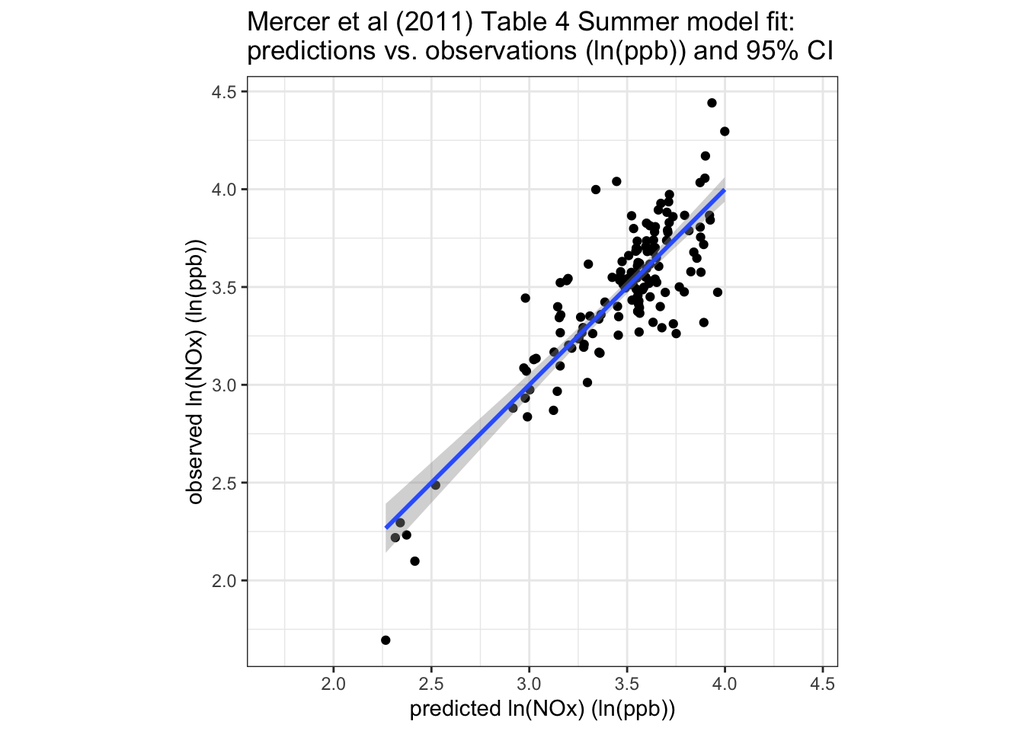

```r
#-----slide 37: plots w/ prediction intervals----

# in ggplot it is easy to get CIs of fitted lines but more work to get prediction intervals.  We show both here.
# Note:  add_predictions doesn't also add uncertainty of predictions
# first get the prediction intervals
# Note:  you can do this twice on the same dataset and get the same 4 variables
# appended twice.  If you use different interval options (interval="confidence"
# vs. interval="prediction" you will get different values in the created
# variables "lwr" and "upr" corresponding to the type of interval.  Note: you
# can't use a dataframe with multiple variables with the same name.

# predict creates the variables fit, lwr, upr
summer2 <- cbind(summer, predict(summer_mod, interval = "prediction"))
# get the plotting range
summer_mod_range <- with(summer2, range(ln_nox, lwr, upr))

# plot with 95% CI on the fitted line, uses default ggplot option
ggplot(summer2, aes(x = fit, y = ln_nox)) +
    geom_point() +
    stat_smooth(method = lm, se = TRUE) +
    coord_fixed() +
    xlim(summer_mod_range) +
    ylim(summer_mod_range) +
    labs(title = "Mercer et al (2011) Table 4 Summer model fit:\npredictions vs. observations (ln(ppb)) and 95% CI",
         x = "predicted ln(NOx) (ln(ppb))",
         y = "observed ln(NOx) (ln(ppb))"
         ) +
    theme_bw()
```

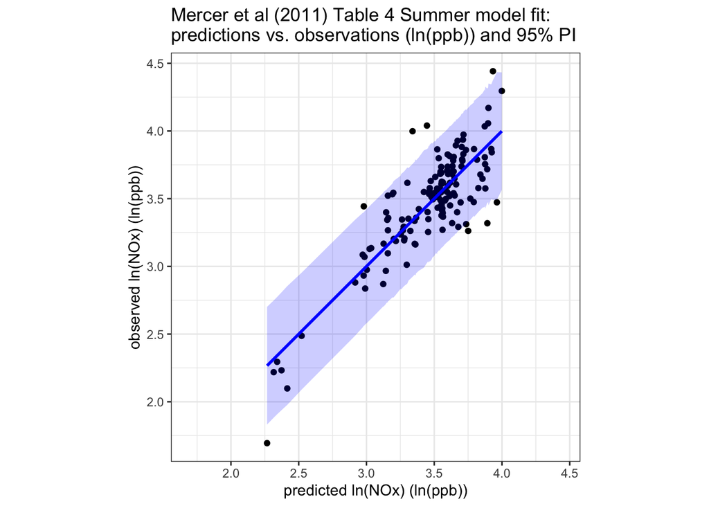

```r
# plot with 95% PI on the fitted line, need extra code to handle this
ggplot(summer2, aes(fit)) +
    geom_point(aes(y = ln_nox)) +
    geom_ribbon(aes(ymin = lwr, ymax = upr), fill = "blue", alpha = 0.2) +
    geom_line(aes(y = fit), color = "blue", size = 1) +
    coord_fixed() +
    xlim(summer_mod_range) +
    ylim(summer_mod_range) +
    labs(title = "Mercer et al (2011) Table 4 Summer model fit:\npredictions vs. observations (ln(ppb)) and 95% PI",
         x = "predicted ln(NOx) (ln(ppb))",
         y = "observed ln(NOx) (ln(ppb))"
         ) +
    theme_bw()
```